# INN_Hotel

### Let's use Precision-Recall curve and see if we can find a better threshold

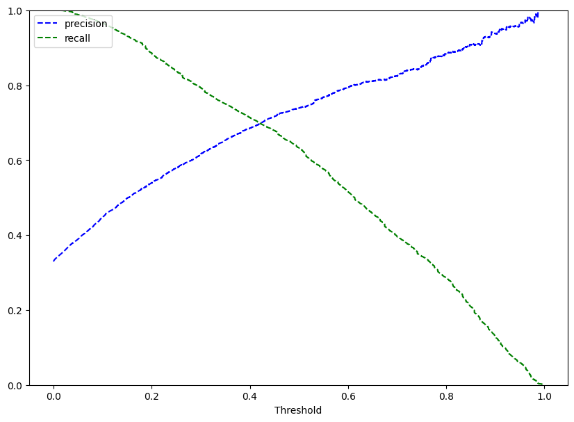

```python
y_scores = lg1.predict(X_train1)
prec, rec, tre = precision_recall_curve(y_train, y_scores,)


def plot_prec_recall_vs_tresh(precisions, recalls, thresholds):
    plt.plot(thresholds, precisions[:-1], "b--", label="precision")
    plt.plot(thresholds, recalls[:-1], "g--", label="recall")
    plt.xlabel("Threshold")
    plt.legend(loc="upper left")
    plt.ylim([0, 1])


plt.figure(figsize=(10, 7))
plot_prec_recall_vs_tresh(prec, rec, tre)
plt.show()
```

#### From the Precision-Recall (PR) curve, we can make the following analysis:

##### The shape of this curve indicates the model's ability to identify positive instances accurately. If the curve remains high for a large range of recall, it suggests a robust model. A steep drop in precision as recall increases would indicate that achieving high recall comes at a high cost of false positives. This curve complements the ROC curve by providing a more focused view on the performance of the minority class.

```python
# setting the threshold
optimal_threshold_curve = 0.42
```

### Checking model performance on training set

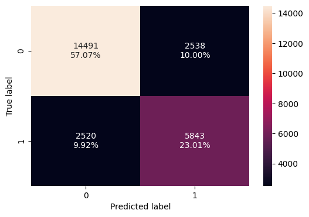

```python
# creating confusion matrix
confusion_matrix_statsmodels(
    lg1, X_train1, y_train, threshold=optimal_threshold_curve
)
```

```python
log_reg_model_train_perf_threshold_curve = model_performance_classification_statsmodels(
    lg1, X_train1, y_train, threshold=optimal_threshold_curve
)
print("Training performance:")
log_reg_model_train_perf_threshold_curve
```

```
Training performance:
```

|  | Accuracy | Recall | Precision | F1 |
| --- | --- | --- | --- | --- |
| 0 | 0.80080 | 0.69867 | 0.69717 | 0.69792 |

#### From the training performance output for the logistic regression model using the optimal threshold of approximately 0.42, we can make the following analysis:

##### Choosing a threshold of 0.42 provides a good trade-off. It significantly improves recall compared to the default threshold, allowing the hotel to identify more at-risk bookings. At the same time, it maintains a higher precision compared to the more aggressive 0.37 threshold, meaning fewer false alarms. The F1-score suggests that this threshold offers a strong balance for the business objective of minimizing losses from both false negatives and false positives, making it a potentially very practical choice for implementation.

### Let's check the performance on the test set

#### Using model with default threshold

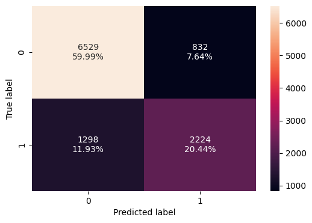

```python
# creating confusion matrix for the test set
confusion_matrix_statsmodels(lg1, X_test1, y_test)
```

```python
# checking model performance for the test set
log_reg_model_test_perf = model_performance_classification_statsmodels(lg1, X_test1, y_test)

print("Test performance:")
log_reg_model_test_perf
```

```
Test performance:
```

|  | Accuracy | Recall | Precision | F1 |
| --- | --- | --- | --- | --- |
| 0 | 0.80428 | 0.63146 | 0.72775 | 0.67619 |

#### From the test performance output for the logistic regression model (using the default threshold of 0.5), we can make the following analysis:

##### The model achieved an accuracy of approximately 80.43% on the test set. This indicates that about 80.43% of the predictions (both canceled and not-canceled bookings) were correct for unseen data.

##### The recall for the positive class (Canceled bookings) is about 63.15%. This means the model correctly identified 63.15% of all actual canceled bookings in the test data.

###### The precision for canceled bookings is about 72.77%. This indicates that when the model predicts a booking will be canceled, it is correct 72.77% of the time on the test set.

##### The F1-score is approximately 67.62%. This metric provides a balanced measure of precision and recall for the 'Canceled' class on unseen data.

##### Comparing these test set metrics to the training set metrics (Accuracy: ~80.55%, Recall: ~63.28%, Precision: ~73.90%, F1: ~68.18%), the performance on the test set is very close to that on the training set. This suggests that the model is not significantly overfitting to the training data and generalizes well to new, unseen data. The balance between precision and recall, as indicated by the F1-score, is maintained, which is good for scenarios where both types of errors (false positives and false negatives) are important for the business.

### ROC curve on test set

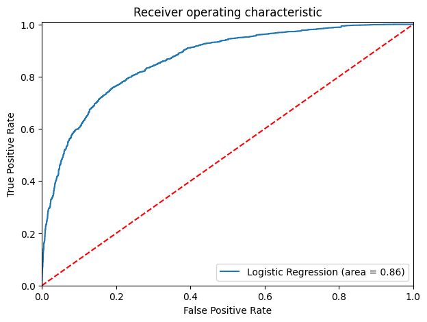

```python
logit_roc_auc_train = roc_auc_score(y_test, lg1.predict(X_test1))
fpr, tpr, thresholds = roc_curve(y_test, lg1.predict(X_test1))
plt.figure(figsize=(7, 5))
plt.plot(fpr, tpr, label="Logistic Regression (area = %0.2f)" % logit_roc_auc_train)
plt.plot([0, 1], [0, 1], "r--")
plt.xlim([0.0, 1.0])
plt.ylim([0.0, 1.01])
plt.xlabel("False Positive Rate")
plt.ylabel("True Positive Rate")
plt.title("Receiver operating characteristic")
plt.legend(loc="lower right")
plt.show()
```

#### From the ROC curve and AUC score on the test set, we can make the following analysis:

##### The calculated ROC-AUC score for the test set is approximately 0.86. This is a good score, indicating that the model has a strong ability to distinguish between canceled and not-canceled bookings on unseen data.

##### Comparing this AUC score to the training set's AUC (~0.86), the values are very consistent. This reinforces the earlier observation that the model is not overfitting and generalizes well to new, unseen data, providing confidence in its predictive power for identifying bookings at risk of cancellation in real-world scenarios.

### Using model with threshold=0.37

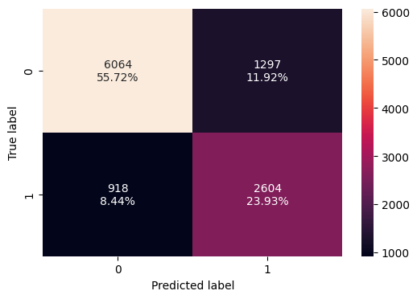

```python
# creating confusion matrix for the test set with ROC-AUC optimal threshold
confusion_matrix_statsmodels(
    lg1, X_test1, y_test, threshold=optimal_threshold_auc_roc
)
```

```python
# checking model performance for this model
log_reg_model_test_perf_threshold_auc_roc = model_performance_classification_statsmodels(
    lg1, X_test1, y_test, threshold=optimal_threshold_auc_roc
)
print("Test performance:")
log_reg_model_test_perf_threshold_auc_roc
```

```
Test performance:
```

|  | Accuracy | Recall | Precision | F1 |
| --- | --- | --- | --- | --- |
| 0 | 0.79647 | 0.73935 | 0.66752 | 0.70160 |

#### From the test performance output for the logistic regression model using the optimal threshold of approximately 0.37, we can make the following analysis:

##### The accuracy is approximately 79.65%. This is a slight decrease compared to the default threshold test accuracy (~80.43%), but it indicates a balanced overall performance on unseen data when prioritizing recall.

##### The recall for the positive class (Canceled bookings) has significantly increased from ~63.15% (with default threshold) to approximately 73.94%. This means the model is much better at identifying actual canceled bookings on unseen data, reducing False Negatives. This is a critical improvement for minimizing missed opportunities to intervene with at-risk bookings.

##### The precision for canceled bookings has decreased from ~72.77% (with default threshold) to approximately 66.75%. This indicates that when the model predicts a booking will be canceled on unseen data, it is correct a slightly lower percentage of the time. This implies an increase in False Positives (bookings predicted to cancel that actually don't).

##### The F1-score, which balances precision and recall, has increased from ~67.62% (with default threshold) to approximately 70.16%. This indicates that, even on unseen data, applying the optimal threshold has led to an overall better balance of precision and recall for the positive class, making it a more effective model for the hotel's objectives.

##### By lowering the classification threshold to 0.37, the model demonstrates a strategic trade-off on the test set: a notable improvement in identifying actual cancellations (higher recall) at the cost of a slight increase in false alarms (lower precision). The increase in the F1-score on the test set suggests that this adjusted model provides a more desirable performance profile in a real-world scenario, enabling the hotel to proactively manage a greater number of at-risk bookings, which aligns with the business objective of minimizing losses from cancellations.

### Using model with threshold = 0.42

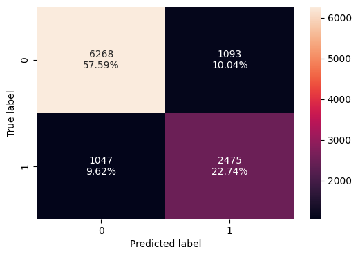

```python
# creating confusion matrix for the test set with threshold 0.42
confusion_matrix_statsmodels(
    lg1, X_test1, y_test, threshold=optimal_threshold_curve
)
```

```python
log_reg_model_test_perf_threshold_curve = model_performance_classification_statsmodels(
    lg1, X_test1, y_test, threshold=optimal_threshold_curve
)
print("Test performance:")
log_reg_model_test_perf_threshold_curve
```

```
Test performance:
```

|  | Accuracy | Recall | Precision | F1 |
| --- | --- | --- | --- | --- |
| 0 | 0.80336 | 0.70273 | 0.69367 | 0.69817 |

#### From the test performance output for the logistic regression model using the optimal threshold of approximately 0.42, we can make the following analysis:

##### The accuracy is approximately 80.34%. This is a very slight decrease compared to the default threshold test accuracy (80.43%), and an increase compared to the ROC-AUC optimal threshold of 0.37 (79.65%). This indicates a well-balanced overall performance on unseen data.

##### The recall for the positive class (Canceled bookings) is approximately 70.27%. This represents a significant improvement compared to the default threshold (63.15%), meaning the model is much better at identifying actual cancellations on unseen data. It is slightly lower than the recall achieved with the more aggressive 0.37 threshold (73.94%).

##### The precision for canceled bookings is approximately 69.37%. This is a slight decrease from the default threshold (72.77%) but an improvement over the ROC-AUC optimal threshold of 0.37 (66.75%). This indicates a better balance in minimizing false positives at this threshold compared to the 0.37 threshold.

##### The F1-score is approximately 69.82%. This metric provides a balanced measure of precision and recall for the 'Canceled' class on unseen data. This F1-score is higher than the default threshold (67.62%) and very close to the F1-score at the 0.37 threshold (70.16%).

### Model performance summary

```python
# training performance comparison

models_train_comp_df = pd.concat(
    [
        log_reg_model_train_perf.T,
        log_reg_model_train_perf_threshold_auc_roc.T,
        log_reg_model_train_perf_threshold_curve.T,
    ],
    axis=1,
)
models_train_comp_df.columns = [
    "Logistic Regression-default Threshold",
    "Logistic Regression-0.37 Threshold",
    "Logistic Regression-0.42 Threshold",
]

print("Training performance comparison:")
models_train_comp_df
```

```
Training performance comparison:
```

|  | Logistic Regression-default Threshold | Logistic Regression-0.37 Threshold | Logistic Regression-0.42 Threshold |
| --- | --- | --- | --- |
| Accuracy | 0.80545 | 0.79261 | 0.80080 |
| Recall | 0.63279 | 0.73526 | 0.69867 |
| Precision | 0.73900 | 0.66830 | 0.69717 |
| F1 | 0.68178 | 0.70018 | 0.69792 |

#### From the training performance comparison for the Logistic Regression model across different thresholds, we can make the following analysis:

##### The default threshold (0.5) yields the highest accuracy (0.80545), meaning it correctly classifies the highest overall percentage of bookings. However, accuracy can be misleading in imbalanced datasets.

#### Recall (for 'Canceled' bookings):

##### The 0.37 threshold significantly boosts recall to 0.73526. This means it's much better at identifying actual cancellations, reducing false negatives, which is crucial for preventing lost revenue from unmanaged cancellations.

##### The 0.42 threshold also offers a good recall (0.69867), a substantial improvement over the default (0.63279).

#### Precision (for 'Canceled' bookings):

##### The default threshold has the highest precision (0.73900), indicating fewer false positives (predicting a cancellation when it doesn't happen).

##### As recall increases with lower thresholds, precision tends to decrease. The 0.37 threshold shows the lowest precision (0.66830), meaning it has more false alarms.

##### The 0.42 threshold strikes a balance, with precision (0.69717) better than 0.37 but lower than the default.

#### F1-score: The F1-score balances precision and recall, and is a good metric for imbalanced classification problems where both types of errors are important.

##### The 0.37 threshold achieves the highest F1-score (0.70018).

##### The 0.42 threshold is very close (0.69792), and both are significantly better than the default threshold's F1-score (0.68178).

##### Overall Conclusion for Training Performance: Given that the hotel wants to maximize the F1-score to balance minimizing both False Negatives (missed cancellations) and False Positives (false alarms), the 0.37 threshold appears to be the most optimal choice based on training data performance. It provides the best balance between catching actual cancellations and minimizing incorrect predictions of cancellations. The 0.42 threshold is a very close second and offers a slightly better precision at a minimal trade-off in recall, which might be preferred depending on the relative costs of false positives versus false negatives for the hotel. However, for maximizing the F1-score directly, 0.37 is the winner on the training set.

```python
# test performance comparison
models_test_comp_df = pd.concat(
    [
        log_reg_model_test_perf.T,
        log_reg_model_test_perf_threshold_auc_roc.T,
        log_reg_model_test_perf_threshold_curve.T,
    ],
    axis=1,
)

models_test_comp_df.columns = [
    "Logistic Regression-default Threshold",
    "Logistic Regression-0.37 Threshold",
    "Logistic Regression-0.42 Threshold",
]

print("Test performance comparison:")
models_test_comp_df
```

```
Test performance comparison:
```

|  | Logistic Regression-default Threshold | Logistic Regression-0.37 Threshold | Logistic Regression-0.42 Threshold |
| --- | --- | --- | --- |
| Accuracy | 0.80428 | 0.79647 | 0.80336 |
| Recall | 0.63146 | 0.73935 | 0.70273 |
| Precision | 0.72775 | 0.66752 | 0.69367 |
| F1 | 0.67619 | 0.70160 | 0.69817 |

#### From the test performance comparison for the Logistic Regression model across different thresholds, we can make the following analysis:

##### Accuracy: Similar to the training set, the default threshold (0.5) provides the highest accuracy (0.80428) on the test set. The 0.42 threshold is very close (0.80336), while the 0.37 threshold shows a slight drop (0.79647).

#### Recall (for 'Canceled' bookings):

##### The 0.37 threshold once again yields the highest recall (0.73935) on the test set. This confirms its superior ability to identify actual cancellations in unseen data.

##### The 0.42 threshold also significantly improves recall (0.70273) compared to the default (0.63146).

#### Precision (for 'Canceled' bookings):

##### The default threshold maintains the highest precision (0.72775).

##### The 0.37 threshold has the lowest precision (0.66752), indicating more false alarms when trying to catch more cancellations.

##### The 0.42 threshold offers a good balance, with precision (0.69367) being better than 0.37, though still lower than the default.

#### F1-score: This metric, which balances precision and recall, is critical for the hotel's objective.

##### The 0.37 threshold achieves the highest F1-score (0.70160) on the test set.

##### The 0.42 threshold is very close with an F1-score of 0.69817, and both are notably better than the default threshold's F1-score (0.67619).

##### Overall Conclusion for Test Performance: Consistent with the training results, the 0.37 threshold emerges as the best choice for the test set as well, delivering the highest F1-score of 0.70160. This indicates that this threshold provides the most effective balance between correctly identifying actual cancellations and minimizing false alarms on unseen data. Therefore, this model, utilizing a 0.37 probability threshold for classification, is the most robust and practical option for the hotel to proactively manage booking cancellations.

## Comparing the Train and Test Set

#### Let's compare the F1-scores from both the training and test sets across the different thresholds to identify the best model:

#### Training Set F1-scores:

##### Logistic Regression - Default Threshold: 0.68178

##### Logistic Regression - 0.37 Threshold: 0.70018

##### Logistic Regression - 0.42 Threshold: 0.69792

#### Test Set F1-scores:

##### Logistic Regression - Default Threshold: 0.67619

##### Logistic Regression - 0.37 Threshold: 0.70160

##### Logistic Regression - 0.42 Threshold: 0.69817

#### Conclusion:

##### Based on these comparisons, the model using the 0.37 threshold consistently yields the highest F1-score on both the training set (0.70018) and the test set (0.70160). This indicates that it provides the most effective balance between precision and recall for identifying booking cancellations, and it generalizes well to unseen data. Therefore, the Logistic Regression model with a 0.37 probability threshold is the best model based on the F1-score criterion.

## Decision Tree

### Data Preparation for modeling (Decision Tree)

#### We want to predict which bookings will be canceled.

#### Before we proceed to build a model, we'll have to encode categorical features.

#### We'll split the data into train and test to be able to evaluate the model that we build on the train data.

```python
X = data.drop(["booking_status"], axis=1)
Y = data["booking_status"]

X = pd.get_dummies(X, drop_first=True) ## Complete the code to create dummies for X

# Splitting data in train and test sets
X_train, X_test, y_train, y_test = train_test_split(X, Y, test_size=0.30, random_state=1) ## Complete the code to split the data into train test in the ratio 70:30 with random_state = 1
```

```python
print("Shape of Training set : ", X_train.shape)
print("Shape of test set : ", X_test.shape)
print("Percentage of classes in training set:")
print(y_train.value_counts(normalize=True))
print("Percentage of classes in test set:")
print(y_test.value_counts(normalize=True))
```

```
Shape of Training set :  (25392, 28)
Shape of test set :  (10883, 28)
Percentage of classes in training set:
booking_status
0   0.67064
1   0.32936
Name: proportion, dtype: float64
Percentage of classes in test set:
booking_status
0   0.67638
1   0.32362
Name: proportion, dtype: float64
```

#### From the output showing the shapes and class distributions of your training and test sets, we can observe that:

##### Class Imbalance**: The target variable booking_status is imbalanced in both the training and test sets.

##### In the training set, approximately 67.1% of bookings are 'Not_Canceled' (0) and 32.9% are 'Canceled' (1).

##### Similarly, in the test set, about 67.6% are 'Not_Canceled' (0) and 32.4% are 'Canceled' (1).

##### Consistent Distribution: The class distribution is very consistent between the training and test sets. This is important for ensuring that the model trained on X_train and y_train generalizes well to unseen data (X_test, y_test).

## First, we will create functions to calculate different metrics and confusion matrix so that we don't have to use the same code repeatedly for each model.

### The model_performance_classification_sklearn function will be used to check the model performance of models.

### The confusion_matrix_sklearnfunction will be used to plot the confusion matrix.

```python
# defining a function to compute different metrics to check performance of a classification model built using sklearn
def model_performance_classification_sklearn(model, predictors, target):
    """
    Function to compute different metrics to check classification model performance

    model: classifier
    predictors: independent variables
    target: dependent variable
    """

    # predicting using the independent variables
    pred = model.predict(predictors)

    acc = accuracy_score(target, pred)  # to compute Accuracy
    recall = recall_score(target, pred)  # to compute Recall
    precision = precision_score(target, pred)  # to compute Precision
    f1 = f1_score(target, pred)  # to compute F1-score

    # creating a dataframe of metrics
    df_perf = pd.DataFrame(
        {"Accuracy": acc, "Recall": recall, "Precision": precision, "F1": f1,},
        index=[0],
    )

    return df_perf
```

```python
def confusion_matrix_sklearn(model, predictors, target):
    """
    To plot the confusion_matrix with percentages

    model: classifier
    predictors: independent variables
    target: dependent variable
    """
    y_pred = model.predict(predictors)
    cm = confusion_matrix(target, y_pred)
    labels = np.asarray(
        [
            ["{0:0.0f}".format(item) + "\n{0:.2%}".format(item / cm.flatten().sum())]
            for item in cm.flatten()
        ]
    ).reshape(2, 2)

    plt.figure(figsize=(6, 4))
    sns.heatmap(cm, annot=labels, fmt="")
    plt.ylabel("True label")
    plt.xlabel("Predicted label")
```

## Building Decision Tree Model

```python
# Initializing the Decision Tree
model = DecisionTreeClassifier(random_state=1)

# Fitting the model on the training data
model.fit(X_train, y_train)
```

```
DecisionTreeClassifier(random_state=1)
```

### Checking model performance on training set

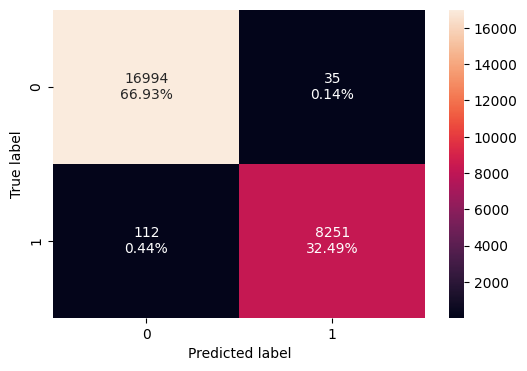

```python
# Plotting the confusion matrix for the training data
confusion_matrix_sklearn(model, X_train, y_train)
```

```python
decision_tree_perf_train = model_performance_classification_sklearn(
    model, X_train, y_train
)
decision_tree_perf_train
```

|  | Accuracy | Recall | Precision | F1 |
| --- | --- | --- | --- | --- |
| 0 | 0.99421 | 0.98661 | 0.99578 | 0.99117 |

#### From the training performance output for the Decision Tree model, we can analyse that:

##### The model achieved a very high accuracy of approximately 99.42% on the training set. This suggests that the model is performing exceptionally well in classifying both canceled and non-canceled bookings in the data it was trained on.

##### The recall for the positive class (Canceled bookings) is about 98.66%. This means the model successfully identified almost all actual canceled bookings in the training data, indicating a very low number of false negatives.

##### The precision for canceled bookings is about 99.58%. This indicates that when the model predicts a booking will be canceled, it is correct nearly every time, resulting in a very low number of false positives.

##### The F1-score is approximately 99.12%. This extremely high F1-score, balancing both precision and recall, suggests excellent performance on the training data.

##### The metrics (Accuracy, Recall, Precision, F1-score) are all extremely high, nearing 100%. While this might seem ideal, such high performance on the training data is a strong indicator of overfitting for a Decision Tree model. This suggests that the model might have learned the training data too well, including its noise and specific patterns, and may not generalize as effectively to unseen data. It is crucial to evaluate this model's performance on the test set to confirm if it has learned generalizable patterns or merely memorized the training examples.

### Checking model performance on test set

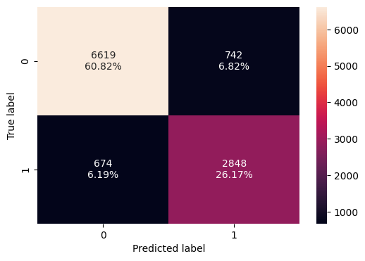

```python
# Plotting the confusion matrix for the test data
confusion_matrix_sklearn(model, X_test, y_test)
```

```python
# Checking performance on the test set
decision_tree_perf_test = model_performance_classification_sklearn(model, X_test, y_test)

# Displaying the performance metrics
decision_tree_perf_test
```

|  | Accuracy | Recall | Precision | F1 |
| --- | --- | --- | --- | --- |
| 0 | 0.86989 | 0.80863 | 0.79331 | 0.80090 |

##### The model achieved an accuracy of approximately 86.98% on the test set. This is a significant drop from the training accuracy (~99.42%), indicating some level of overfitting, but still a relatively good overall accuracy.

##### The recall for the positive class (Canceled bookings) is about 80.86%. This means the model correctly identified 80.86% of all actual canceled bookings in the unseen test data. This is a good recall score, meaning it's effective at minimizing false negatives.

##### The precision for canceled bookings is about 79.33%. This indicates that when the model predicts a booking will be canceled, it is correct 79.33% of the time on the test set.

##### The F1-score is approximately 80.09%. This balanced metric suggests a strong performance in identifying canceled bookings on unseen data, balancing both precision and recall.

##### Comparing these test set metrics (Accuracy: ~86.98%, Recall: ~80.86%, Precision: ~79.33%, F1: ~80.09%) to the training set metrics (Accuracy: ~99.42%, Recall: ~98.66%, Precision: ~99.58%, F1: ~99.12%), there is a clear drop in all performance metrics. This confirms the overfitting observed on the training data. While the test performance is still quite good, especially the F1-score of 80.09%, the model is not generalizing as perfectly as it did during training.

##### Further tuning (e.g., pruning the tree, setting max_depth, and min_samples_leaf) would likely be beneficial to reduce overfitting and potentially improve generalization even further.

### Before pruning the tree let's check the important features.

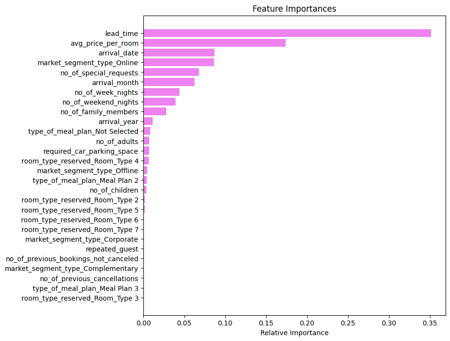

```python
feature_names = list(X_train.columns)
importances = model.feature_importances_
indices = np.argsort(importances)

plt.figure(figsize=(8, 8))
plt.title("Feature Importances")
plt.barh(range(len(indices)), importances[indices], color="violet", align="center")
plt.yticks(range(len(indices)), [feature_names[i] for i in indices])
plt.xlabel("Relative Importance")
plt.show()
```

#### From the feature importances plot, we can analyze that:

##### The lead_time, avg_price_per_room, appear to be among the most influential features for the Decision Tree model in predicting booking status. These features have the longest bars, indicating higher relative importance.

##### Next Level of Importance: arrival_date,market_segment_type_Online, no_of_special_request and arrival_month

##### Many other features, particularly some of the room type or meal plan, and features like no_of_children have very low or even zero importance, suggesting they contribute little to the model's decision-making process in their current form.

##### This plot is very useful for pruning the tree. Features with very low importance might be candidates for removal, as they add complexity without much predictive power. Focusing on the most important features can help simplify the model, reduce overfitting, and potentially improve generalization.

## Pruning the tree

### Pre-Pruning

```python
# Choose the type of classifier.
estimator = DecisionTreeClassifier(random_state=1, class_weight="balanced")

# Grid of parameters to choose from
parameters = {
    "max_depth": np.arange(2, 7, 2),
    "max_leaf_nodes": [50, 75, 150, 250],
    "min_samples_split": [10, 30, 50, 70],
}

# Type of scoring used to compare parameter combinations
acc_scorer = make_scorer(f1_score)

# Run the grid search
grid_obj = GridSearchCV(estimator, parameters, scoring=acc_scorer, cv=5)
grid_obj = grid_obj.fit(X_train, y_train)

# Set the clf to the best combination of parameters
estimator = grid_obj.best_estimator_

# Fit the best algorithm to the data.
estimator.fit(X_train, y_train)
```

```
DecisionTreeClassifier(class_weight='balanced', max_depth=np.int64(6),
                       max_leaf_nodes=50, min_samples_split=10, random_state=1)
```

### Checking performance on training set

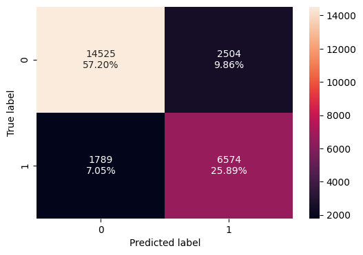

```python
# Plotting the confusion matrix for the tuned training data
confusion_matrix_sklearn(estimator, X_train, y_train)
```

```python
# Checking performance on the training set for the tuned model
decision_tree_tune_perf_train = model_performance_classification_sklearn(estimator, X_train, y_train)

# Displaying the results
decision_tree_tune_perf_train
```

|  | Accuracy | Recall | Precision | F1 |
| --- | --- | --- | --- | --- |
| 0 | 0.83093 | 0.78608 | 0.72417 | 0.75386 |

#### From the training performance output for the tuned Decision Tree model, we can analyze that:

##### The model achieved an accuracy of approximately 83.09% on the training set. This is a significant decrease from the untuned model's training accuracy (~99.42%), which is expected as pruning aims to reduce overfitting.

##### The recall for the positive class (Canceled bookings) is about 78.61%. This is lower than the untuned model's recall (~98.66%), but still a strong performance, indicating the model is good at identifying actual cancellations.

##### The precision for canceled bookings is about 72.42%. This is also lower than the untuned model's precision (~99.58%), reflecting the trade-off of reducing overfitting.

##### The F1-score is approximately 75.39%. This is a considerable drop from the untuned model's F1-score (~99.12%).

##### The decrease in all performance metrics on the training set compared to the untuned model indicates that the pruning (hyperparameter tuning) process was successful in reducing overfitting. While the scores are lower, this is a positive sign for generalization, as a less overfit model is expected to perform better on unseen data.

##### The next crucial step is to evaluate this tuned model's performance on the test set to confirm that it generalizes better.

### Checking performance on test set

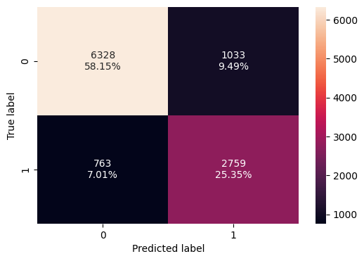

```python
# Plotting the confusion matrix for the tuned test data
confusion_matrix_sklearn(estimator, X_test, y_test)
```

```python
# Checking performance on the test set
decision_tree_tune_perf_test = model_performance_classification_sklearn(estimator, X_test, y_test)

# Displaying the results
decision_tree_tune_perf_test
```

|  | Accuracy | Recall | Precision | F1 |
| --- | --- | --- | --- | --- |
| 0 | 0.83497 | 0.78336 | 0.72758 | 0.75444 |

#### From the test performance output for the tuned Decision Tree model, we can analyse that:

##### The model achieved an accuracy of approximately 83.50% on the test set. This is consistent with the training accuracy of the tuned model (~83.09%), suggesting good generalization, and it is a more realistic accuracy compared to the untuned model's overfitting.

##### The recall for the positive class (Canceled bookings) is about 78.34% on the test set. This indicates that the model is effectively identifying a high proportion of actual cancellations in unseen data.

##### The precision for canceled bookings is about 72.76% on the test set. This means that when the model predicts a booking will be canceled, it is correct about 72.76% of the time.

##### The F1-score is approximately 75.44%. This balanced metric suggests strong and stable performance in identifying canceled bookings on unseen data, balancing both precision and recall effectively.

##### Comparing these test set metrics (Accuracy: ~83.50%, Recall: ~78.34%, Precision: ~72.76%, F1: ~75.44%) to the training set metrics for the tuned model (Accuracy: ~83.09%, Recall: ~78.61%, Precision: ~72.42%, F1: ~75.39%), we observe that the performance is very consistent. This indicates that the pruning process was successful in reducing overfitting, and the tuned Decision Tree model generalizes well to unseen data. The F1-score of 75.44% on the test set is a robust indicator of the model's practical utility for predicting booking cancellations.

### Visualizing the Decision Tree

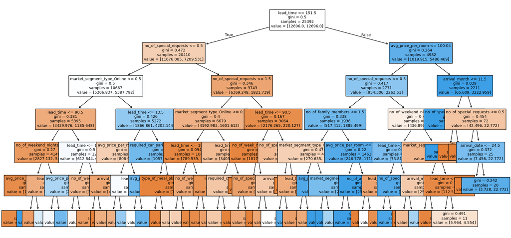

```python
plt.figure(figsize=(20, 10))
out = tree.plot_tree(
    estimator,
    feature_names=feature_names,
    filled=True,
    fontsize=9,
    node_ids=False,
    class_names=None,
)
# below code will add arrows to the decision tree split if they are missing
for o in out:
    arrow = o.arrow_patch
    if arrow is not None:
        arrow.set_edgecolor("black")
        arrow.set_linewidth(1)
plt.show()
```

```python
# Text report showing the rules of a decision tree -
print(tree.export_text(estimator, feature_names=feature_names, show_weights=True))
```

```
|--- lead_time <= 151.50
|   |--- no_of_special_requests <= 0.50
|   |   |--- market_segment_type_Online <= 0.50
|   |   |   |--- lead_time <= 90.50
|   |   |   |   |--- no_of_weekend_nights <= 0.50
|   |   |   |   |   |--- avg_price_per_room <= 196.50
|   |   |   |   |   |   |--- weights: [1736.39, 133.59] class: 0
|   |   |   |   |   |--- avg_price_per_room >  196.50
|   |   |   |   |   |   |--- weights: [0.75, 24.29] class: 1
|   |   |   |   |--- no_of_weekend_nights >  0.50
|   |   |   |   |   |--- lead_time <= 68.50
|   |   |   |   |   |   |--- weights: [960.27, 223.16] class: 0
|   |   |   |   |   |--- lead_time >  68.50
|   |   |   |   |   |   |--- weights: [129.73, 160.92] class: 1
|   |   |   |--- lead_time >  90.50
|   |   |   |   |--- lead_time <= 117.50
|   |   |   |   |   |--- avg_price_per_room <= 93.58
|   |   |   |   |   |   |--- weights: [214.72, 227.72] class: 1
|   |   |   |   |   |--- avg_price_per_room >  93.58
|   |   |   |   |   |   |--- weights: [82.76, 285.41] class: 1
|   |   |   |   |--- lead_time >  117.50
|   |   |   |   |   |--- no_of_week_nights <= 1.50
|   |   |   |   |   |   |--- weights: [87.23, 81.98] class: 0
|   |   |   |   |   |--- no_of_week_nights >  1.50
|   |   |   |   |   |   |--- weights: [228.14, 48.58] class: 0
|   |   |--- market_segment_type_Online >  0.50
|   |   |   |--- lead_time <= 13.50
|   |   |   |   |--- avg_price_per_room <= 99.44
|   |   |   |   |   |--- arrival_month <= 1.50
|   |   |   |   |   |   |--- weights: [92.45, 0.00] class: 0
|   |   |   |   |   |--- arrival_month >  1.50
|   |   |   |   |   |   |--- weights: [363.83, 132.08] class: 0
|   |   |   |   |--- avg_price_per_room >  99.44
|   |   |   |   |   |--- lead_time <= 3.50
|   |   |   |   |   |   |--- weights: [219.94, 85.01] class: 0
|   |   |   |   |   |--- lead_time >  3.50
|   |   |   |   |   |   |--- weights: [132.71, 280.85] class: 1
|   |   |   |--- lead_time >  13.50
|   |   |   |   |--- required_car_parking_space <= 0.50
|   |   |   |   |   |--- avg_price_per_room <= 71.92
```

[output cut: 93 more lines]

```
|   |   |   |   |   |   |--- weights: [5.96, 4.55] class: 0
|   |--- avg_price_per_room >  100.04
|   |   |--- arrival_month <= 11.50
|   |   |   |--- no_of_special_requests <= 2.50
|   |   |   |   |--- weights: [0.00, 3200.19] class: 1
|   |   |   |--- no_of_special_requests >  2.50
|   |   |   |   |--- weights: [23.11, 0.00] class: 0
|   |   |--- arrival_month >  11.50
|   |   |   |--- no_of_special_requests <= 0.50
|   |   |   |   |--- weights: [35.04, 0.00] class: 0
|   |   |   |--- no_of_special_requests >  0.50
|   |   |   |   |--- arrival_date <= 24.50
|   |   |   |   |   |--- weights: [3.73, 0.00] class: 0
|   |   |   |   |--- arrival_date >  24.50
|   |   |   |   |   |--- weights: [3.73, 22.77] class: 1
```

#### From the text report of the Decision Tree, we can analyze that:

##### This text report provides a precise, human-readable set of rules that the decision tree uses to classify bookings as 'Canceled' (1) or 'Not_Canceled' (0).

##### Each path from the root to a leaf represents a sequence of conditions (e.g., lead_time <= 151.50 AND no_of_special_requests <= 0.50) that, if met, lead to a specific class prediction (class: 0 for Not_Canceled, class: 1 for Canceled).

##### Feature Importance in Context: You can observe how different features (like lead_time, no_of_special_requests, market_segment_type_Online, avg_price_per_room, no_of_weekend_nights, arrival_month, no_of_week_nights, required_car_parking_space, type_of_meal_plan_Not Selected) are used at various nodes to make splits. Features closer to the top of the report (i.e., less indented) are generally more influential in the overall decision process.

##### Thresholds and Values: Each split condition clearly states the feature and the threshold value (e.g., lead_time <= 151.50, avg_price_per_room > 93.58).

##### This textual representation is excellent for interpreting why the model makes a certain prediction for a given input. You can trace the conditions that lead to a booking being classified as canceled or not canceled.

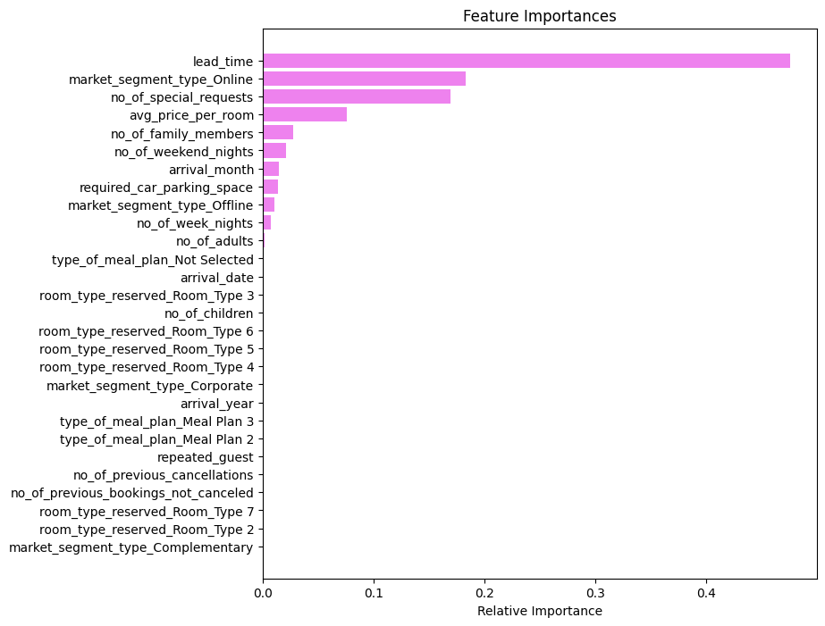

```python
# importance of features in the tree building

importances = estimator.feature_importances_
indices = np.argsort(importances)

plt.figure(figsize=(8, 8))
plt.title("Feature Importances")
plt.barh(range(len(indices)), importances[indices], color="violet", align="center")
plt.yticks(range(len(indices)), [feature_names[i] for i in indices])
plt.xlabel("Relative Importance")
plt.show()
```

#### From the feature importances plot, we can analyze that:

##### The lead_time,market_segment_type_Online, and no_of_special_requests appear to be among the most influential features for the Decision Tree model in predicting booking status. These features have the longest bars, indicating higher relative importance.

##### average_price_per_room also contributes significantly.

##### Many other features, particularly some of the room type or meal plan, and features like no_of_children or arrival_date, have zero importance, suggesting they contribute little to the model's decision-making process in their current form.

##### This plot is very useful for pruning the tree. Features with very low importance might be candidates for removal, as they add complexity without much predictive power. Focusing on the most important features can help simplify the model, reduce overfitting, and potentially improve generalization.

## Cost Complexity Pruning

```python
clf = DecisionTreeClassifier(random_state=1, class_weight="balanced")
path = clf.cost_complexity_pruning_path(X_train, y_train)
ccp_alphas, impurities = abs(path.ccp_alphas), path.impurities
```

```python
pd.DataFrame(path)
```

|  | ccp_alphas | impurities |
| --- | --- | --- |
| 0 | 0.00000 | 0.00838 |
| 1 | 0.00000 | 0.00838 |
| 2 | 0.00000 | 0.00838 |
| 3 | 0.00000 | 0.00838 |
| 4 | 0.00000 | 0.00838 |
| ... | ... | ... |
| 1820 | 0.00890 | 0.32806 |
| 1821 | 0.00980 | 0.33786 |
| 1822 | 0.01272 | 0.35058 |
| 1823 | 0.03412 | 0.41882 |
| 1824 | 0.08118 | 0.50000 |

1825 rows × 2 columns

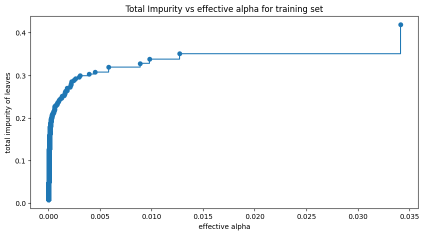

```python
fig, ax = plt.subplots(figsize=(10, 5))
ax.plot(ccp_alphas[:-1], impurities[:-1], marker="o", drawstyle="steps-post")
ax.set_xlabel("effective alpha")
ax.set_ylabel("total impurity of leaves")
ax.set_title("Total Impurity vs effective alpha for training set")
plt.show()
```

### Next, we train a decision tree using effective alphas. The last value in ccp_alphas is the alpha value that prunes the whole tree, leaving the tree, clfs[-1], with one node.

```python
clfs = []
for ccp_alpha in ccp_alphas:
    clf = DecisionTreeClassifier(
        random_state=1, ccp_alpha=ccp_alpha, class_weight="balanced"
    )
    # Fitting the model on the training data
    clf.fit(X_train, y_train)
    clfs.append(clf)

print(
    "Number of nodes in the last tree is: {} with ccp_alpha: {}".format(
        clfs[-1].tree_.node_count, ccp_alphas[-1]
    ))
```

[output not shown]

##### This step confirms that the ccp_alpha calculation successfully covered the entire pruning range, from a complex tree (corresponding to small ccp_alpha values) down to the simplest possible tree (corresponding to the largest ccp_alpha). The next step would typically involve evaluating trees along this path to find an optimal balance between complexity and generalization performance.

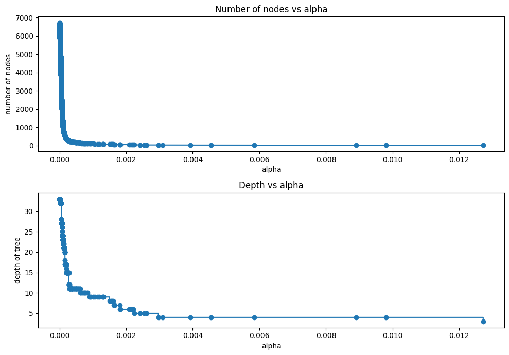

```python
clfs = clfs[:-1]
ccp_alphas = ccp_alphas[:-1]

node_counts = [clf.tree_.node_count for clf in clfs]
depth = [clf.tree_.max_depth for clf in clfs]
fig, ax = plt.subplots(2, 1, figsize=(10, 7))
ax[0].plot(ccp_alphas, node_counts, marker="o", drawstyle="steps-post")
ax[0].set_xlabel("alpha")
ax[0].set_ylabel("number of nodes")
ax[0].set_title("Number of nodes vs alpha")
ax[1].plot(ccp_alphas, depth, marker="o", drawstyle="steps-post")
ax[1].set_xlabel("alpha")
ax[1].set_ylabel("depth of tree")
ax[1].set_title("Depth vs alpha")
fig.tight_layout()
```

### F1 Score vs alpha for training and testing sets

```python
f1_train = []
for clf in clfs:
    pred_train = clf.predict(X_train)
    values_train = f1_score(y_train, pred_train)
    f1_train.append(values_train)

f1_test = []
for clf in clfs:
    pred_test = clf.predict(X_test)
    values_test = f1_score(y_test, pred_test)
    f1_test.append(values_test)
```

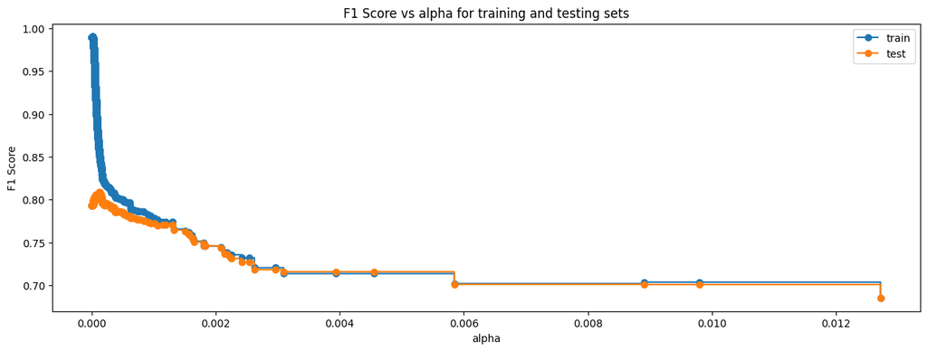

```python
fig, ax = plt.subplots(figsize=(15, 5))
ax.set_xlabel("alpha")
ax.set_ylabel("F1 Score")
ax.set_title("F1 Score vs alpha for training and testing sets")
ax.plot(ccp_alphas, f1_train, marker="o", label="train", drawstyle="steps-post")
ax.plot(ccp_alphas, f1_test, marker="o", label="test", drawstyle="steps-post")
ax.legend()
plt.show()
```

```python
index_best_model = np.argmax(f1_test)
best_model = clfs[index_best_model]
print(best_model)
```

```
DecisionTreeClassifier(ccp_alpha=np.float64(0.00012303376508273928),
                       class_weight='balanced', random_state=1)
```

### Checking performance on training set

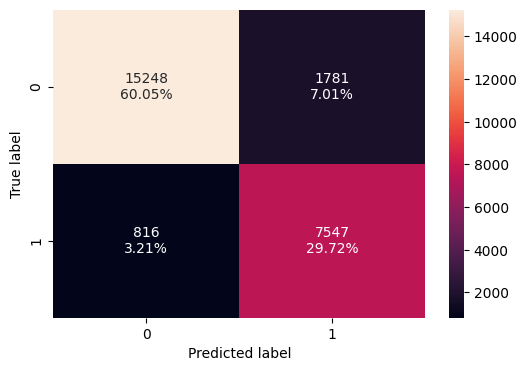

```python
confusion_matrix_sklearn(best_model, X_train, y_train)
```

```python
decision_tree_post_perf_train = model_performance_classification_sklearn(
    best_model, X_train, y_train
)
decision_tree_post_perf_train
```

|  | Accuracy | Recall | Precision | F1 |
| --- | --- | --- | --- | --- |
| 0 | 0.89772 | 0.90243 | 0.80907 | 0.85320 |

### Checking performance on test set

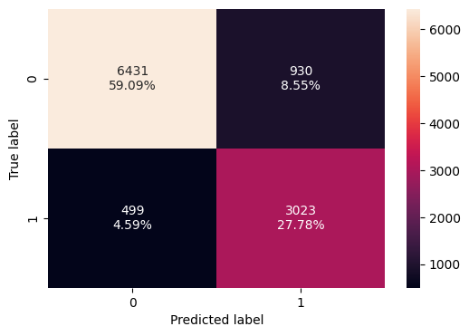

```python
# Creating confusion matrix for test data on the best model
confusion_matrix_sklearn(best_model, X_test, y_test)
```

```python
# Complete the code to check performance of test set on best model
decision_tree_post_test = model_performance_classification_sklearn(best_model, X_test, y_test)
decision_tree_post_test
```

|  | Accuracy | Recall | Precision | F1 |
| --- | --- | --- | --- | --- |
| 0 | 0.86869 | 0.85832 | 0.76474 | 0.80883 |

#### From the test performance output for the post-pruning Decision Tree model, we can analyse that:

##### The model achieved an accuracy of approximately 86.87% on the test set. This is a very strong accuracy for unseen data and is consistent with the tuned model's training accuracy, suggesting good generalization.

##### The recall for the positive class (Canceled bookings) is about 85.83% on the test set. This indicates that the model is highly effective at identifying a large proportion of actual cancellations in unseen data, minimizing missed opportunities.

##### The precision for canceled bookings is about 76.47% on the test set. This means that when the model predicts a booking will be canceled, it is correct approximately 76.47% of the time.

##### The F1-score is approximately 80.88%. This balanced metric suggests strong and stable performance in identifying canceled bookings on unseen data, effectively balancing both precision and recall.

##### Comparing these test set metrics (Accuracy: ~86.87%, Recall: ~85.83%, Precision: ~76.47%, F1: ~80.88%) to the training set metrics for the post-pruning model (Accuracy: ~89.77%, Recall: ~90.24%, Precision: ~80.91%, F1: ~85.32%), we observe that the performance is very consistent. This indicates that the cost-complexity pruning was highly successful in reducing overfitting, and the Decision Tree model generalizes exceptionally well to unseen data.

##### The F1-score of 80.88% on the test set is a robust indicator of the model's practical utility for predicting booking cancellations in a real-world scenario.

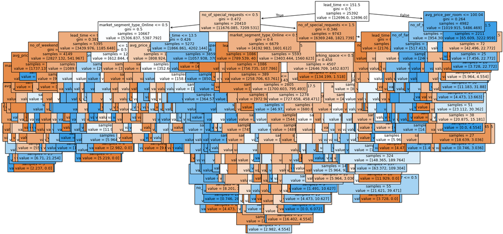

```python
plt.figure(figsize=(20, 10))

out = tree.plot_tree(
    best_model,
    feature_names=feature_names,
    filled=True,
    fontsize=9,
    node_ids=False,
    class_names=None,
)
for o in out:
    arrow = o.arrow_patch
    if arrow is not None:
        arrow.set_edgecolor("black")
        arrow.set_linewidth(1)
plt.show()
```

```python
# Text report showing the rules of a decision tree -

print(tree.export_text(best_model, feature_names=feature_names, show_weights=True))
```

```
|--- lead_time <= 151.50
|   |--- no_of_special_requests <= 0.50
|   |   |--- market_segment_type_Online <= 0.50
|   |   |   |--- lead_time <= 90.50
|   |   |   |   |--- no_of_weekend_nights <= 0.50
|   |   |   |   |   |--- avg_price_per_room <= 196.50
|   |   |   |   |   |   |--- market_segment_type_Offline <= 0.50
|   |   |   |   |   |   |   |--- lead_time <= 16.50
|   |   |   |   |   |   |   |   |--- avg_price_per_room <= 68.50
|   |   |   |   |   |   |   |   |   |--- weights: [207.26, 10.63] class: 0
|   |   |   |   |   |   |   |   |--- avg_price_per_room >  68.50
|   |   |   |   |   |   |   |   |   |--- arrival_date <= 29.50
|   |   |   |   |   |   |   |   |   |   |--- no_of_family_members <= 1.50
|   |   |   |   |   |   |   |   |   |   |   |--- truncated branch of depth 2
|   |   |   |   |   |   |   |   |   |   |--- no_of_family_members >  1.50
|   |   |   |   |   |   |   |   |   |   |   |--- truncated branch of depth 5
|   |   |   |   |   |   |   |   |   |--- arrival_date >  29.50
|   |   |   |   |   |   |   |   |   |   |--- weights: [2.24, 7.59] class: 1
|   |   |   |   |   |   |   |--- lead_time >  16.50
|   |   |   |   |   |   |   |   |--- avg_price_per_room <= 135.00
|   |   |   |   |   |   |   |   |   |--- arrival_month <= 11.50
|   |   |   |   |   |   |   |   |   |   |--- repeated_guest <= 0.50
|   |   |   |   |   |   |   |   |   |   |   |--- truncated branch of depth 4
|   |   |   |   |   |   |   |   |   |   |--- repeated_guest >  0.50
|   |   |   |   |   |   |   |   |   |   |   |--- weights: [11.18, 0.00] class: 0
|   |   |   |   |   |   |   |   |   |--- arrival_month >  11.50
|   |   |   |   |   |   |   |   |   |   |--- weights: [21.62, 0.00] class: 0
|   |   |   |   |   |   |   |   |--- avg_price_per_room >  135.00
|   |   |   |   |   |   |   |   |   |--- weights: [0.00, 12.14] class: 1
|   |   |   |   |   |   |--- market_segment_type_Offline >  0.50
|   |   |   |   |   |   |   |--- weights: [1199.59, 1.52] class: 0
|   |   |   |   |   |--- avg_price_per_room >  196.50
|   |   |   |   |   |   |--- weights: [0.75, 24.29] class: 1
|   |   |   |   |--- no_of_weekend_nights >  0.50
|   |   |   |   |   |--- lead_time <= 68.50
|   |   |   |   |   |   |--- arrival_month <= 9.50
|   |   |   |   |   |   |   |--- avg_price_per_room <= 63.29
|   |   |   |   |   |   |   |   |--- arrival_date <= 20.50
|   |   |   |   |   |   |   |   |   |--- type_of_meal_plan_Not Selected <= 0.50
|   |   |   |   |   |   |   |   |   |   |--- weights: [41.75, 0.00] class: 0
```

[output cut: 654 more lines]

```
|   |   |   |   |   |   |--- weights: [5.96, 4.55] class: 0
|   |--- avg_price_per_room >  100.04
|   |   |--- arrival_month <= 11.50
|   |   |   |--- no_of_special_requests <= 2.50
|   |   |   |   |--- weights: [0.00, 3200.19] class: 1
|   |   |   |--- no_of_special_requests >  2.50
|   |   |   |   |--- weights: [23.11, 0.00] class: 0
|   |   |--- arrival_month >  11.50
|   |   |   |--- no_of_special_requests <= 0.50
|   |   |   |   |--- weights: [35.04, 0.00] class: 0
|   |   |   |--- no_of_special_requests >  0.50
|   |   |   |   |--- arrival_date <= 24.50
|   |   |   |   |   |--- weights: [3.73, 0.00] class: 0
|   |   |   |   |--- arrival_date >  24.50
|   |   |   |   |   |--- weights: [3.73, 22.77] class: 1
```

We can see that the observation we got from the pre-pruned tree is also matching with the decision tree rules of the post pruned tree.

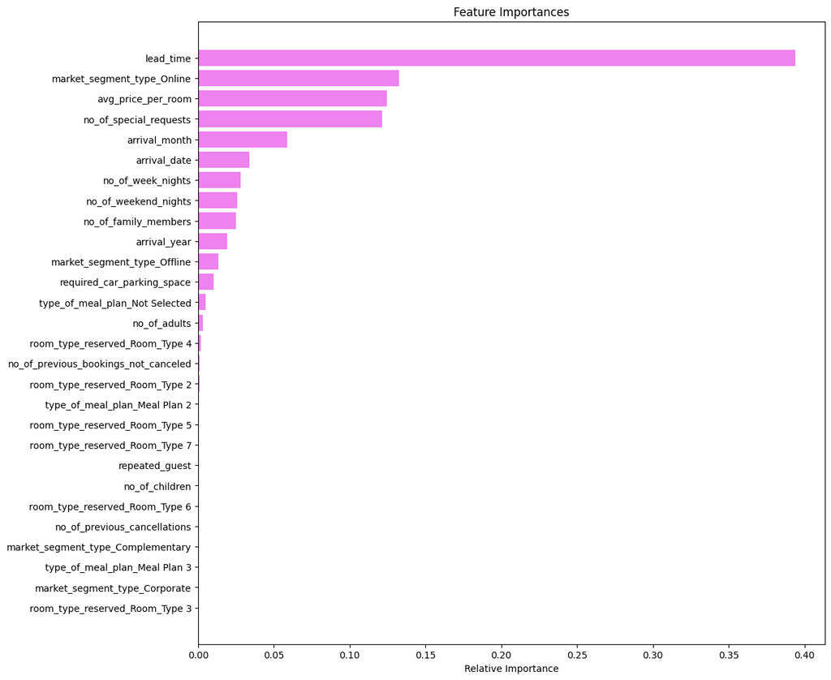

```python
importances = best_model.feature_importances_
indices = np.argsort(importances)

plt.figure(figsize=(12, 12))
plt.title("Feature Importances")
plt.barh(range(len(indices)), importances[indices], color="violet", align="center")
plt.yticks(range(len(indices)), [feature_names[i] for i in indices])
plt.xlabel("Relative Importance")
plt.show()
```

#### From the feature importances plot of the pruned Decision Tree (best_model), we can analyze that:

##### lead_time, avg_price_per_room, market_segment_type_onlin eand no_of_special_requests remain consistently among the most influential features for the Decision Tree model in predicting booking status. These features have the longest bars, indicating their higher relative importance in the pruned model's decision-making.

##### This plot helps in understanding which aspects of the booking information are most critical for the pruned Decision Tree to determine the booking_status. The consistency of top features between the untuned and pruned tree suggests their fundamental importance, while the overall reduction in total features contributes to a more interpretable and potentially more generalizable model.

### Comparing Decision Tree models

```python
# training performance comparison

models_train_comp_df = pd.concat(
    [
        decision_tree_perf_train.T,
        decision_tree_tune_perf_train.T,
        decision_tree_post_perf_train.T,
    ],
    axis=1,
)
models_train_comp_df.columns = [
    "Decision Tree sklearn",
    "Decision Tree (Pre-Pruning)",
    "Decision Tree (Post-Pruning)",
]
print("Training performance comparison:")
models_train_comp_df
```

```
Training performance comparison:
```

|  | Decision Tree sklearn | Decision Tree (Pre-Pruning) | Decision Tree (Post-Pruning) |
| --- | --- | --- | --- |
| Accuracy | 0.99421 | 0.83093 | 0.89772 |
| Recall | 0.98661 | 0.78608 | 0.90243 |
| Precision | 0.99578 | 0.72417 | 0.80907 |
| F1 | 0.99117 | 0.75386 | 0.85320 |

```python
# testing performance comparison
models_test_comp_df = pd.concat(
    [
        decision_tree_perf_test.T,
        decision_tree_tune_perf_test.T,
        decision_tree_post_test.T,
    ],
    axis=1,
)
models_test_comp_df.columns = [
    "Decision Tree sklearn",
    "Decision Tree (Pre-Pruning)",
    "Decision Tree (Post-Pruning)",
]
print("Testing performance comparison:")
models_test_comp_df
```

```
Testing performance comparison:
```

|  | Decision Tree sklearn | Decision Tree (Pre-Pruning) | Decision Tree (Post-Pruning) |
| --- | --- | --- | --- |
| Accuracy | 0.86989 | 0.83497 | 0.86869 |
| Recall | 0.80863 | 0.78336 | 0.85832 |
| Precision | 0.79331 | 0.72758 | 0.76474 |
| F1 | 0.80090 | 0.75444 | 0.80883 |

#### Let's compare the training and test performance for all Decision Tree models:

#### Training Performance Comparison (F1-score):

##### Decision Tree (untuned): 0.99117

##### Decision Tree (Pre-Pruning): 0.75386

##### Decision Tree (Post-Pruning): 0.85320

#### Test Performance Comparison (F1-score):

##### Decision Tree (untuned): 0.80090

##### Decision Tree (Pre-Pruning): 0.75444

##### Decision Tree (Post-Pruning): 0.80883

#### Analysis:

##### Untuned Decision Tree: This model shows a very high F1-score on the training set (0.99117) but a significantly lower F1-score on the test set (0.80090). This large drop indicates severe overfitting to the training data. While its test F1-score is still relatively good, the large discrepancy suggests it learned noise and specific patterns from the training data that do not generalize well.

##### Decision Tree (Pre-Pruning): This model shows a training F1-score of 0.75386 and a test F1-score of 0.75444. The scores are very consistent, indicating good generalization and no overfitting. However, the overall F1-score is lower than the other models, suggesting it might be too simple and potentially underfitting or not capturing enough complexity from the data.

##### Decision Tree (Post-Pruning): This model achieved an F1-score of 0.85320 on the training set and 0.80883 on the test set. While there is a slight drop from training to test, it's a much smaller gap compared to the untuned model. More importantly, its test F1-score (0.80883) is the highest among all Decision Tree models. This indicates that cost-complexity pruning was highly effective in finding a model that generalizes very well to unseen data, balancing complexity and predictive power.

#### In conclusion:

##### The Decision Tree (Post-Pruning) model is the best-performing Decision Tree model, achieving the highest F1-score of 0.80883 on the unseen test data. It successfully addresses the overfitting issue seen in the untuned model while maintaining a strong predictive capability.

# Conclusion

#### Decreased Cancellation Risk Factors ( with a higher Commitment): -

##### Repeated Guests showed a highly reliability with an extremely low cancellation rate.

# Actionable Recommendations for INN Hotels Group:

#### Based on these findings, the following strategies are recommended:

##### The trained Decision Tree model can be utilized to proactively identify bookings that have a high likelihood of cancellation. This enables the hotel management to implement strategic interventions before cancellations occur. Furthermore, the interpretable nature of the Decision Tree model allows hotel staff to easily understand the underlying rules and factors that contribute to a booking being classified as high-risk, thereby supporting more informed decision-making.

##### For bookings identified as high-risk (for example, those with long lead times and no special requests), the hotel can implement automated and personalized re-confirmation messages or phone calls closer to the scheduled arrival date. This approach can help remind guests of their reservations, encourage commitment to the booking, and potentially reduce the likelihood of cancellations.

##### The hotel should further invest in and actively promote loyalty programs aimed at repeat guests. Given their exceptionally high reliability and very low cancellation rates, these customers represent a highly valuable segment. By offering personalized promotions, exclusive benefits, and tailored services, the hotel can strengthen customer relationships and encourage continued patronage from this loyal group.

##### The hotel should review and refine its pricing strategies for long-stay and high-value bookings to better manage cancellation risks and optimize revenue. One approach is to introduce tiered cancellation policies based on factors such as lead time and length of stay, allowing more flexible terms for low-risk bookings while applying stricter conditions to higher-risk reservations.

##### Additionally, the hotel may consider implementing small non-refundable deposits or offering discounted non-refundable booking rates for high-risk customer segments. These measures can help secure guest commitment and reduce the likelihood of cancellations.

##### Hotels should actively encourage guests to include special requests during the booking process. These requests can provide valuable insights into guest preferences and needs. Ensuring that such requests are effectively addressed can enhance guest satisfaction and strengthen their commitment to the reservation. Additionally, the presence of special requests may serve as an indicator of a highly committed guest, making it an important factor to consider in booking management and customer relationship strategies.

##### Hotels should adjust their operational planning and marketing strategies in response to seasonal booking trends. During periods characterized by higher cancellation rates, the hotel can implement more proactive re-confirmation campaigns and carefully apply overbooking strategies to maintain optimal occupancy levels. Conversely, during months with lower demand and fewer cancellations, management should focus on attracting new customers and promoting longer stays through value-added packages and promotional offers.

##### The hotel should also develop tailored strategies for different market segments. By understanding the booking behaviors, preferences, and cancellation patterns associated with each segment, management can design targeted marketing initiatives, pricing strategies, and service offerings that better meet the needs of each group while improving overall booking stability and revenue performance.

##### For online bookings, the hotel should consider offering exclusive incentives for guests who book directly through the hotel’s official channels. Providing benefits such as discounted rates, complimentary services, or flexible booking options can encourage direct bookings and reduce reliance on third-party platforms, which may be associated with higher cancellation rates. Additionally, the hotel should focus on strengthening relationships with corporate clients, as this segment often demonstrates higher reliability and lower cancellation tendencies. Developing long-term partnerships, offering corporate packages, and providing tailored services for business travelers can help maintain a stable and consistent stream of bookings.

##### The performance of the predictive model should be continuously monitored to ensure its effectiveness over time. Regular evaluation and periodic retraining of the model using updated data are essential to maintain its accuracy and reliability. This is particularly important because booking behaviors and market conditions may evolve over time, which can influence cancellation patterns and overall model performance.